# NYPD Shooting Data

2024-05-10

## NYPD Shooting Data

This is an analysis of NYPD shooting data from 2006 through the end of 2023. We will go through the steps of the data science process and create two visualizations and a model.

### Step 1: Import the Data and Enable Libraries

Let’s first take the time to enable the various libraries we will use:

```r
library(lubridate)        # Functions to work with dates and time stamps
library(tidyverse)        # Import all the tidyverse packages (here we use ggplot2, dplyr, and tidyr)
library(leaflet)          # Create interactive web maps
library(utils)            # R utility functions
library(Matrix)           # Sparse and dense matrix functions
library(arules)           # Analyze transactional data (we will use this package to implement the apriori model)
library(forecast)         # package for time series forecasting
library(base)             # The base R package
```

The data we are importing is data of all shootings responded to by the NYPD between 2006 and 2023. The dataset includes key information about each shooting, including age/race/gender of each victim and each perpetrator, location of the incident, the date and time of each incident, and other data that is not of concern to us at this time.

We are sourcing data from the following URL:

https://data.cityofnewyork.us/api/views/833y-fsy8/rows.csv

We will import the data directly from this URL:

```r
nypd <- read.csv("https://data.cityofnewyork.us/api/views/833y-fsy8/rows.csv")
head(nypd)
```

```
##   INCIDENT_KEY OCCUR_DATE OCCUR_TIME      BORO LOC_OF_OCCUR_DESC PRECINCT
## 1    244608249 05/05/2022   00:10:00 MANHATTAN            INSIDE       14
## 2    247542571 07/04/2022   22:20:00     BRONX           OUTSIDE       48
## 3     84967535 05/27/2012   19:35:00    QUEENS                        103
## 4    202853370 09/24/2019   21:00:00     BRONX                         42
## 5     27078636 02/25/2007   21:00:00  BROOKLYN                         83
## 6    230311078 07/01/2021   23:07:00 MANHATTAN                         23
##   JURISDICTION_CODE LOC_CLASSFCTN_DESC             LOCATION_DESC
## 1                 0         COMMERCIAL               VIDEO STORE
## 2                 0             STREET                    (null)
## 3                 0
## 4                 0
## 5                 0
## 6                 2                    MULTI DWELL - PUBLIC HOUS
##   STATISTICAL_MURDER_FLAG PERP_AGE_GROUP PERP_SEX PERP_RACE VIC_AGE_GROUP
```

[output cut: 20 more lines]

### Step 2: Tidy the Data

Now that our data is loaded, we can clean it. We don’t need all 21 variables present in the dataset, so we will delete the columns we don’t need.

The unnecessary columns we are removing are as follows:

- INCIDENT_KEY (Column 1)
- LOC_OF_OCCUR_DESC (Column 5)
- JURISDICTION_CODE (Column 7)
- LOC_CLASSFCTN_DESC (Column 8)
- X_COORD_CD (Column 17)
- Y_COORD_CD (Column 18)
- Lon_Lat (Column 21)

Let’s remove these columns from our dataset:

```r
columns_to_remove <- c(1, 5, 7, 8, 17, 18, 21)
nypd_clean <- nypd[, -columns_to_remove]
```

There are some columns in the CSV that use empty cells and null strings “(null)” interchangeably. We will remove all the null strings and replace them with empty cells for consistency:

```r
nypd_clean[] <- lapply(nypd_clean, function(x) gsub("\\(null\\)", "", x))
```

All the data types are originally strings. Let’s convert them to usable data types. We will convert the following columns:

- Latitude: character -> numeric
- Longitude: character -> numeric
- OCCUR_DATE: character -> Date
- OCCUR_TIME: character -> Period
- STATISTICAL_MURDER_FLAG: character -> logical

We will be using the Latitude and Longitude columns. Some of these values are not numerical, so we will convert them to numerical values:

```r
nypd_clean$Latitude <- as.numeric(nypd_clean$Latitude)
nypd_clean$Longitude <- as.numeric(nypd_clean$Longitude)

nypd_clean$OCCUR_DATE <- mdy(nypd_clean$OCCUR_DATE)
nypd_clean$OCCUR_TIME <- hms(nypd_clean$OCCUR_TIME)

nypd_clean$STATISTICAL_MURDER_FLAG <- as.logical(nypd_clean$STATISTICAL_MURDER_FLAG)
```

### Step 3: Transform the Data

Now that our data is cleaned, we can look for ways to transform it. We can combine the OCCUR_DATE and OCCUR_TIME columns into one DATETIME column that we will use for analysis later:

```r
nypd_clean  %>% drop_na(OCCUR_DATE)
nypd_clean  %>% drop_na(OCCUR_TIME)

nypd_clean$DATETIME <- as_datetime(nypd_clean$OCCUR_DATE + nypd_clean$OCCUR_TIME)
```

### Step 4: Visualize the Data

Let’s visualize the data.

#### Visualization 1: Shootings by Borough

One of the features we find in the data set is the New York City borough in which the shooting occurred. I would like to know which borough has experienced the most shootings and how each compares to one another.

First, get the count of shootings for each borough and the percentage of total shootings that each borough accounts for:

```r
borough_counts <- nypd_clean %>% count(BORO)
borough_counts <- borough_counts[order(-borough_counts$n), ]

total_shootings <- sum(borough_counts$n)
borough_counts <- mutate(borough_counts, percentage = n/total_shootings * 100)
```

Now, let’s set a custom color pallete and generate our chart:

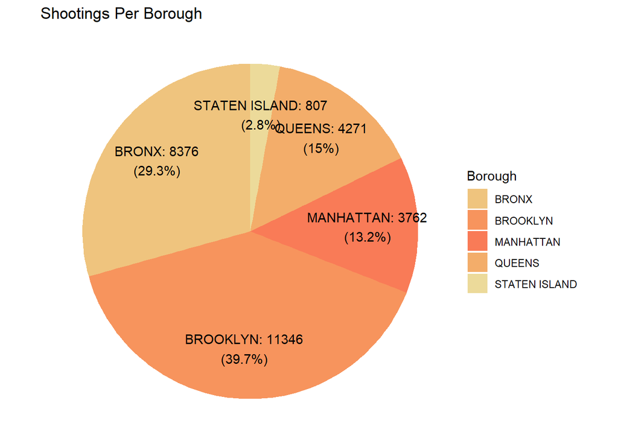

```r
custom_colors <- c("MANHATTAN" = "#f97b57",
                   "BROOKLYN" = "#f7945d",
                   "QUEENS" = "#f3ad6a",
                   "BRONX" = "#efc47e",
                   "STATEN ISLAND" = "#ecda9a")


ggplot(borough_counts, aes(x = "", y = n, fill = BORO)) +
  geom_bar(stat = "identity", width = 1) +
  coord_polar("y", start = 0) +
  theme_void() +
  geom_text(aes(x=1.2, label = paste0(BORO, ": ", n, "\n(", round(percentage, 1), "%)")), position = position_stack(vjust = 0.5)) +
  labs(title = "Shootings Per Borough", fill = "Borough")+
  scale_fill_manual(values = custom_colors)
```

##### Communicate the Data

Now we have a pie chart that shows the amount of shootings by borough and the percentage of all New York City shootings each borough accounts for. This data could be used to make recommendations about where a larger police presence is needed or where more community safety programs could be put in place.

#### Visualization 2: Location of each shooting

We have coordinates for each shooting that is in the data set. Let’s create a map of where each shooting took place to see if there are any trends. We will use the leaflet package to plot the coordinates over a map that we can zoom in and out of.

```r
leaflet() %>% addTiles() %>%
  addCircleMarkers(data = nypd_clean,
                   lat = ~Latitude, lng = ~Longitude,
                   color = "red",
                   radius = 0.05)
```

[interactive chart not shown]

##### Communicate the Data

Here, we can see where each shooting took place. We can see that there are higher concentrations of shootings in certain areas of the city, while other areas are much more spread out. This data could be useful for people who are determining where they want to live in the city.

### Step 5: Model the Data

Let’s perform association rule mining to see if there is a relationship between the time of a shooting and the precinct it happens in. In layman’s terms, the question is as follows: If there is a shooting in {Precinct X}, then it is likely to happen at {this time of day}.”

The first step is to discretize our data. Let’s do this by dividing hours of the day into the time slots Morning, Afternoon, Evening, and Night and saving this data to a new column.

```r
morning_start <- as.POSIXct("05:00:00", format = "%H:%M:%S")
afternoon_start <- as.POSIXct("12:00:00", format = "%H:%M:%S")
evening_start <- as.POSIXct("16:00:00", format = "%H:%M:%S")
night_start <- as.POSIXct("21:00:00", format = "%H:%M:%S")
night_end <- as.POSIXct("04:59:59", format = "%H:%M:%S")


nypd_clean$hour <- format(nypd_clean$DATETIME, "%H")
nypd_clean$hour <- as.numeric(nypd_clean$hour)

nypd_clean$TIME_SLOT <- ifelse(nypd_clean$hour >= 21 | nypd_clean$hour < 5, "Night",
                               ifelse(nypd_clean$hour >= 5 & nypd_clean$hour < 12, "Morning",
                                      ifelse(nypd_clean$hour >= 12 & nypd_clean$hour < 16, "Afternoon", "Evening")))
```

Next, let’s create the apriori model, a model that will help us associate categorical variables to one another.

```r
nypd_subset <- nypd_clean[, c("TIME_SLOT", "PRECINCT")]
nypd_subset$TIME_SLOT <- factor(nypd_subset$TIME_SLOT)
nypd_subset$PRECINCT <- factor(nypd_subset$PRECINCT)

nypd_transactions <- as(nypd_subset, "transactions")

rules <- apriori(nypd_transactions, parameter = list(support = 0.001, confidence = 0.5, maxlen = 2))
```

```
## Apriori
##
## Parameter specification:
##  confidence minval smax arem  aval originalSupport maxtime support minlen
##         0.5    0.1    1 none FALSE            TRUE       5   0.001      1
##  maxlen target  ext
##       2  rules TRUE
##
## Algorithmic control:
##  filter tree heap memopt load sort verbose
##     0.1 TRUE TRUE  FALSE TRUE    2    TRUE
##
## Absolute minimum support count: 28
##
## set item appearances ...[0 item(s)] done [0.00s].
## set transactions ...[81 item(s), 28562 transaction(s)] done [0.00s].
## sorting and recoding items ... [74 item(s)] done [0.00s].
## creating transaction tree ... done [0.00s].
## checking subsets of size 1 2 done [0.00s].
## writing ... [62 rule(s)] done [0.00s].
## creating S4 object  ... done [0.00s].
```

```r
inspect(sort(rules, by = "lift"))
```

```
##      lhs               rhs               support     confidence coverage
## [1]  {PRECINCT=10}  => {TIME_SLOT=Night} 0.001960647 0.7567568  0.002590855
## [2]  {PRECINCT=9}   => {TIME_SLOT=Night} 0.002835936 0.7105263  0.003991317
## [3]  {PRECINCT=13}  => {TIME_SLOT=Night} 0.001505497 0.7049180  0.002135705
## [4]  {PRECINCT=7}   => {TIME_SLOT=Night} 0.002835936 0.6750000  0.004201386
## [5]  {PRECINCT=102} => {TIME_SLOT=Night} 0.005391779 0.6724891  0.008017646
## [6]  {PRECINCT=115} => {TIME_SLOT=Night} 0.004341433 0.6702703  0.006477137
## [7]  {PRECINCT=30}  => {TIME_SLOT=Night} 0.005461802 0.6666667  0.008192704
## [8]  {PRECINCT=100} => {TIME_SLOT=Night} 0.004131363 0.6629213  0.006232057
## [9]  {PRECINCT=5}   => {TIME_SLOT=Night} 0.001540508 0.6567164  0.002345774
## [10] {PRECINCT=114} => {TIME_SLOT=Night} 0.008997969 0.6473552  0.013899587
## [11] {PRECINCT=109} => {TIME_SLOT=Night} 0.002765913 0.6422764  0.004306421
## [12] {PRECINCT=113} => {TIME_SLOT=Night} 0.018276031 0.6258993  0.029199636
## [13] {PRECINCT=34}  => {TIME_SLOT=Night} 0.007317415 0.6238806  0.011728871
## [14] {PRECINCT=24}  => {TIME_SLOT=Night} 0.002450809 0.6194690  0.003956306
```

[output cut: 111 more lines]

##### Communicate the Data

When we inspect the results of the model, we can learn the following. Take the first line for example:

- {PRECINCT=10} => {TIME_SLOT=Night} 0.001960647 0.7567568 0.002590855 1.3362897 56

This rule indicates that if an incident occurs in Precinct 10, there’s a high likelihood (confidence of 0.757) that it will happen during the Night (TIME_SLOT=Night). The lift value of 1.336 suggests that this association is 1.336 times more likely to occur than if the antecedent and consequent were independent.

You can interpret other rules in a similar manner. Each rule provides insight into the association between precincts and time slots.

This data could be useful in predicting what times of day that a shooting is most likely to occur in each precinct. Each precinct could have a better idea of how to deploy their emergency responders and how to staff firehouses and police stations to be ready for when a shooting would most likely occur in that area.

### Conclusion

##### General Thoughts

Data as simple as New York City shootings can provide a trove of information that can be used to better society and prevent tragedies from occurring. Predicting where and when a shooting is most likely to occur can help law enforcement and other first responders be in the right place at the right time to treat shooting injuries or prevent shootings from happening in the first place. This data can be used to make the city a safer place in the future.

##### Bias

There are lots of ways for bias to creep into this data. The data itself is each shooting that the NYPD responds to, so the data itself isn’t necessarily biased. However, the data contains demographic information including race and gender. It can be easy to skew analysis in favor of showing that certain races or genders are more responsible for shootings or are disproportionately affected as victims of shootings. Using the data to fit your narrative can be used for racist purposes, which is never okay. I made sure to leave age, race, and gender out of my analysis to be sure I didn’t paint anybody in the wrong light.